# Supplementary Material for “Spatially balanced sampling methods are always more precise than random ones for estimating the size of aggregated populations”

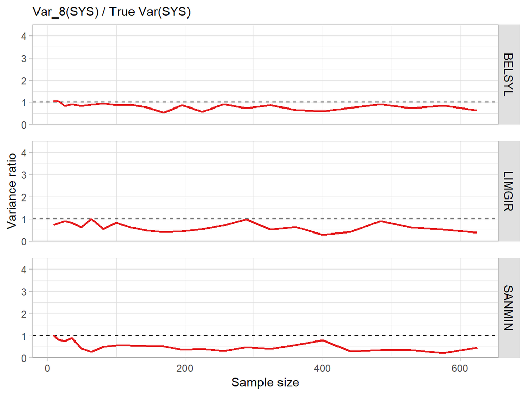

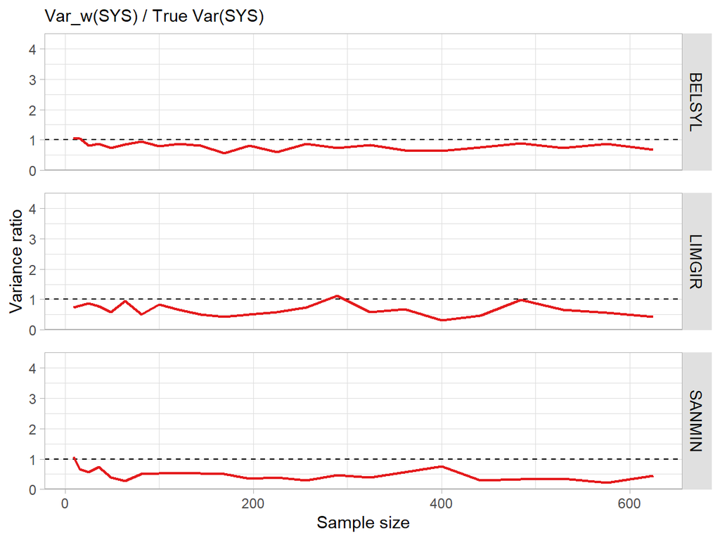

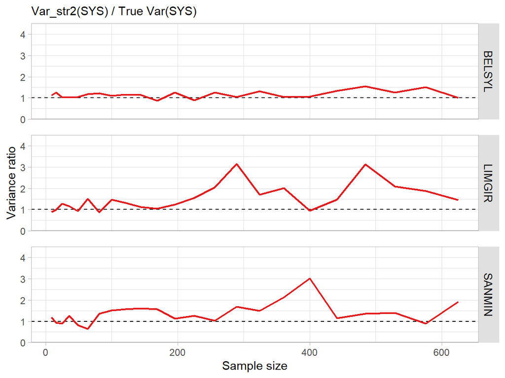

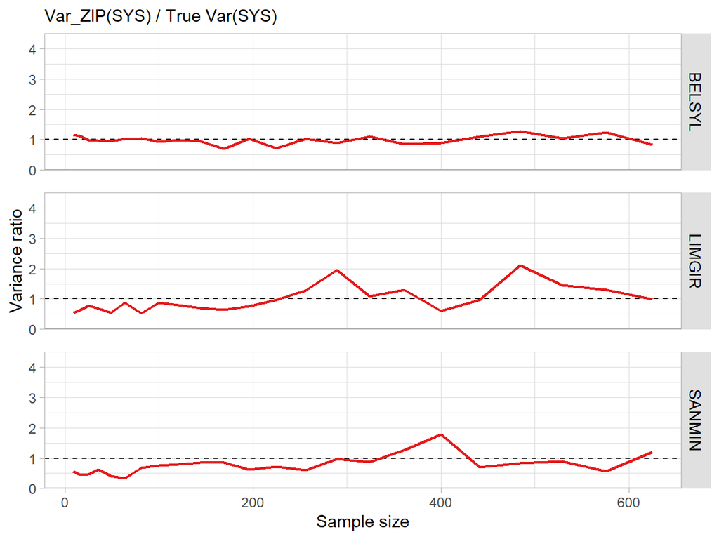

**Figure S4.11:** Ratio of the estimated sampling variance using five variance estimators (V_textbook, V_8, V_w, V_str2, V_ZIP) over the true sampling variance for systematic sampling (SYS), as a function of sample size for the three natural populations.

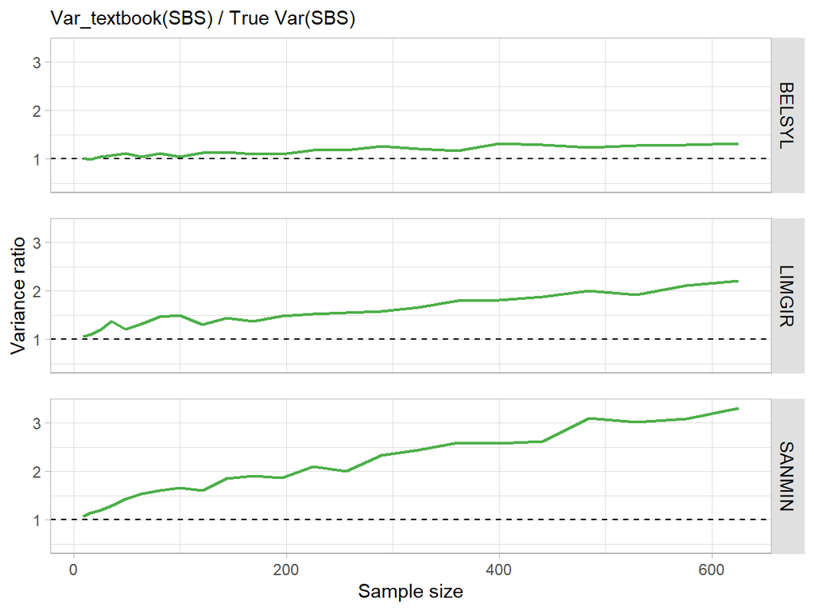

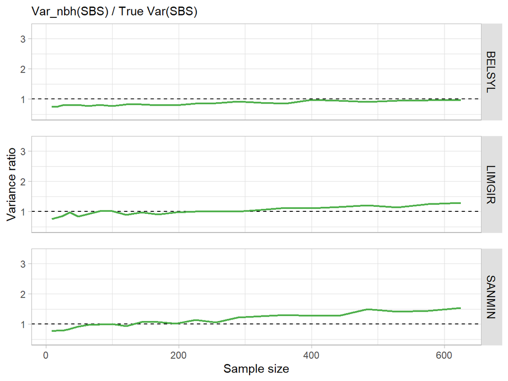

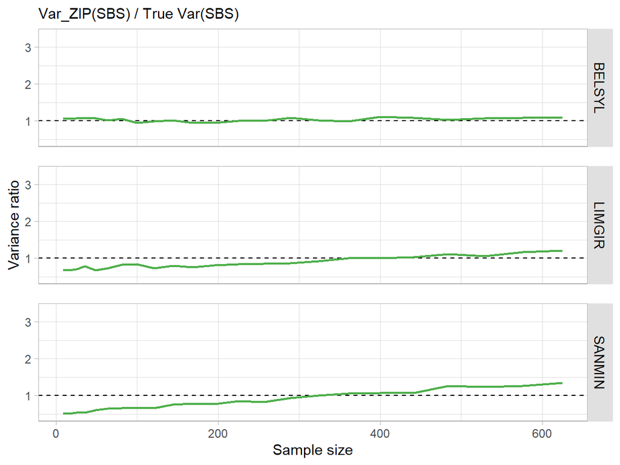

**Figure S4.12:** Ratio of the estimated sampling variance using three variance estimators (V_textbook, V_nbh and V_ZIP) over the true sampling variance for spatially balanced sampling (SYS), as a function of sample size for the three natural populations.

**Interpretation:**

- For the population of *Bellis sylvestris* (BELSYL) there is little difference in true sampling variance between the three sampling methods (Fig. 4), and the textbook estimator provides nearly unbiased estimates for SYS and SBS. For the other two populations, V_textbook substantially overestimates the sampling variance (Fig. S4.10).
- For SYS, V_8 and V_w tend to underestimate the sampling variance as for the virtual populations. The estimates obtained with V_str2 are unbiased or overestimated, but less overestimated than V_textbook. V_ZIP tends to underestimate sampling variance, but less than V_8 and V_w.
- For SBS, V_nbh provides nearly unbiased estimates despite a tendency to overestimation for larger sample sizes. The V_ZIP estimator also performs fairly well, but less than V_nbh.

### 2.2 Estimator coverage ratio

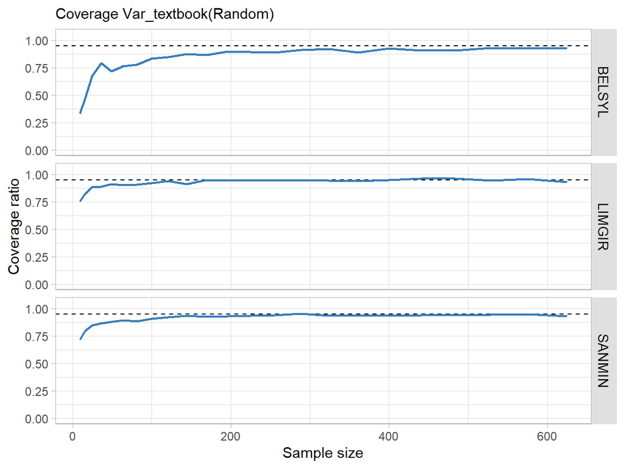

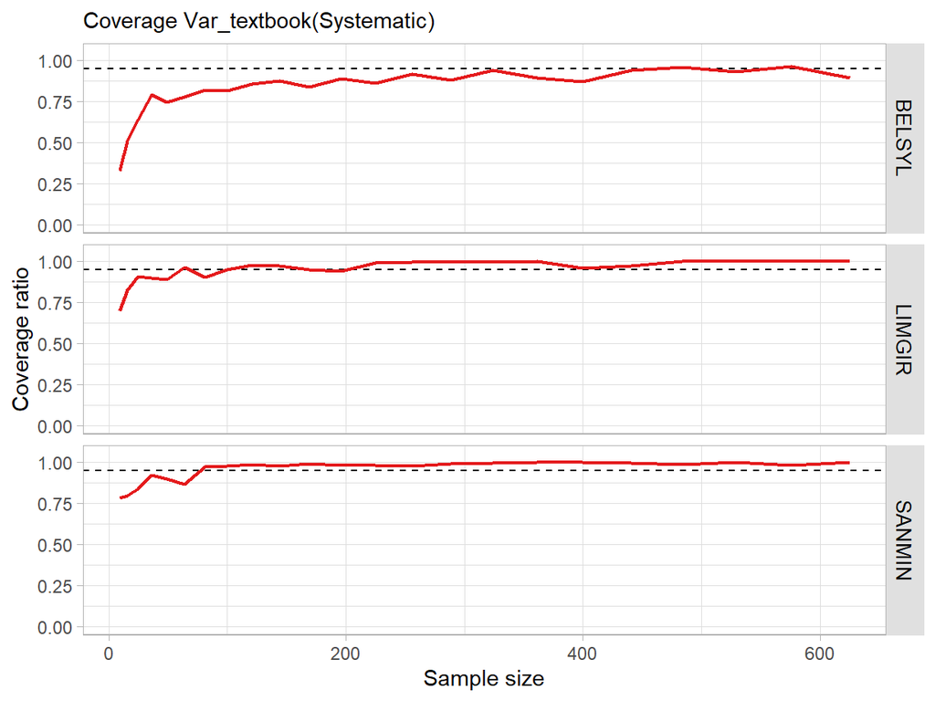

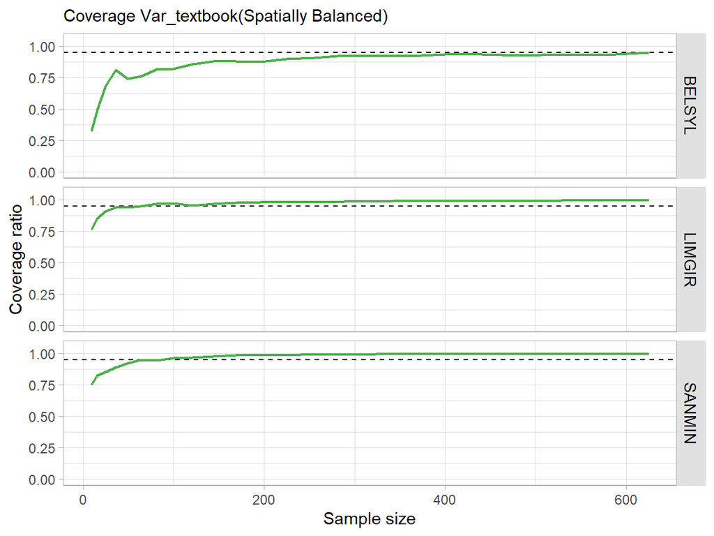

**Figure S4.13:** Coverage ratio of the “textbook” estimator for simple random sampling (SRS), systematic sampling (SYS) and spatially balanced sampling (SBS), as a function of sample size for the three natural populations.

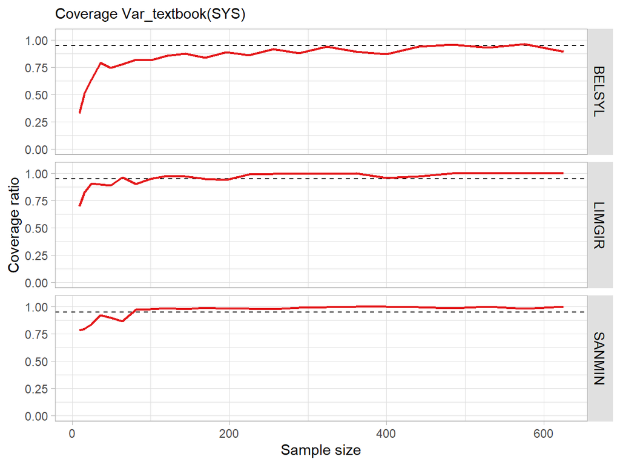

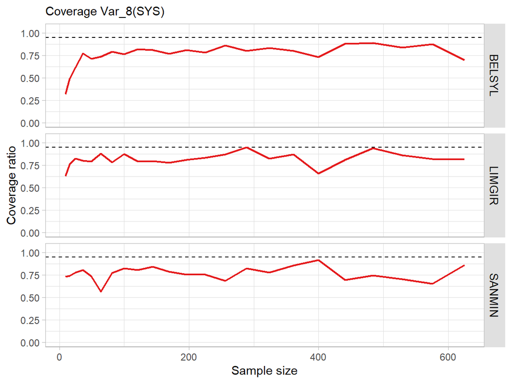

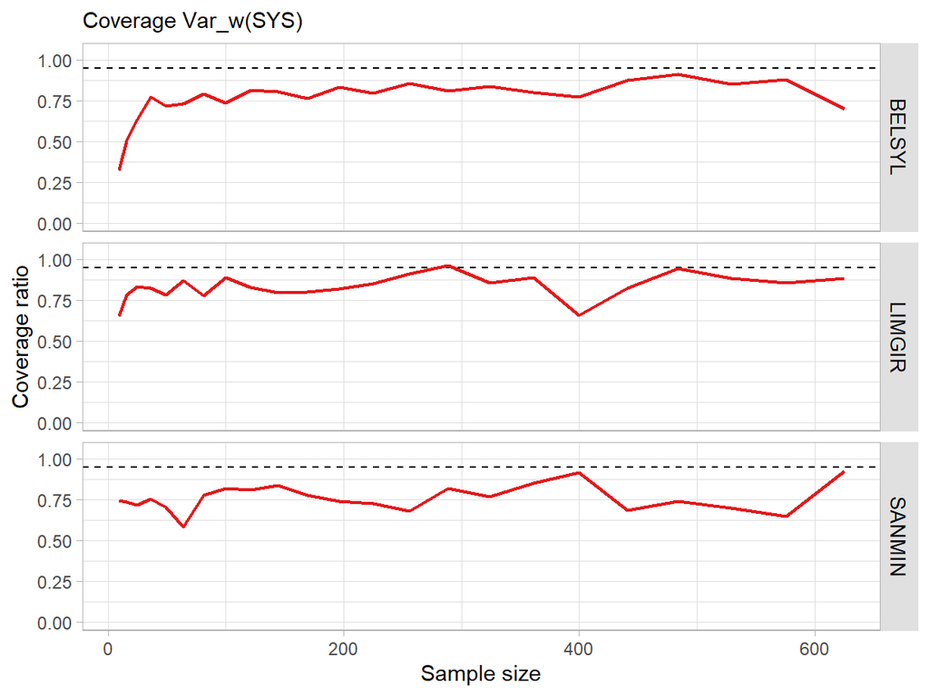

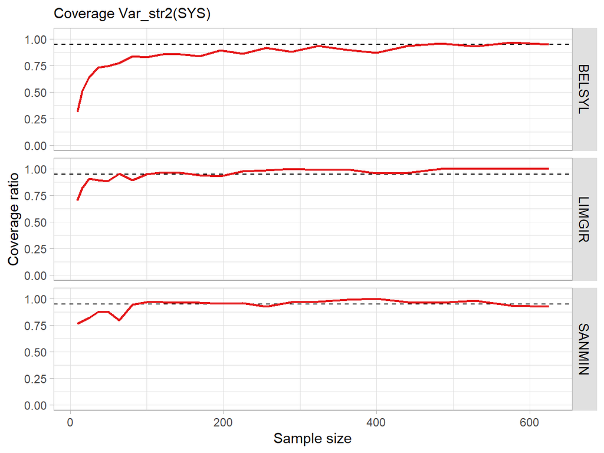

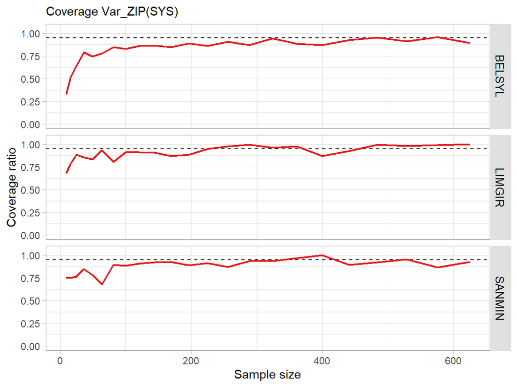

**Figure S4.14:** Coverage ratio of five variance estimators (V_textbook, V_8, V_w, V_str2, V_ZIP) for systematic sampling (SYS), as a function of sample size for the three natural populations.

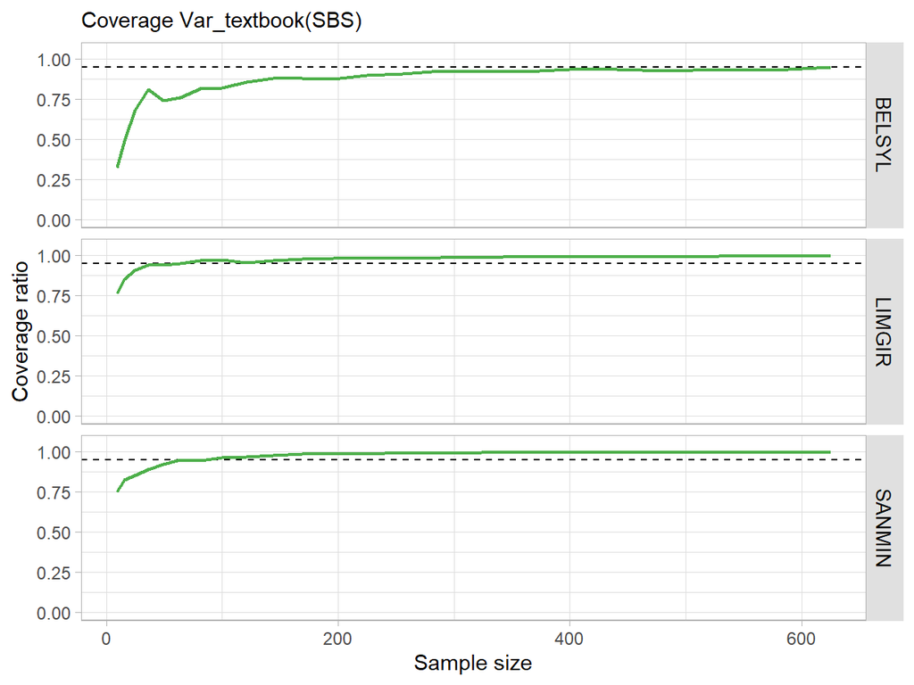

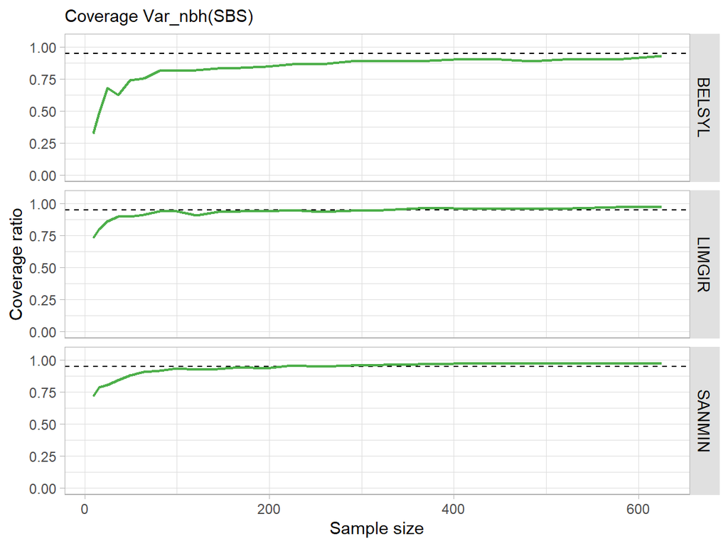

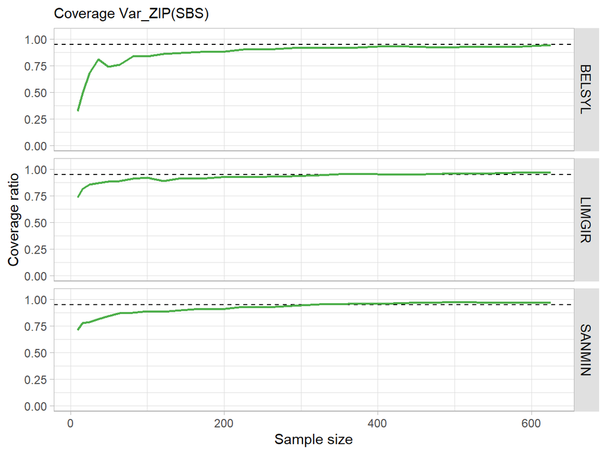

**Interpretation:**  
For small sample sizes (i.e. below n = 75), all estimators have poor coverage for the three sampling methods. For sample sizes above n = 75, all estimators have a coverage ratio around 0.95, except for V_8 and V_w for SYS, which is due to their tendency to underestimation.

### 2.3 Comparison of the estimated variance for SYS and SBS to the estimated variance for SRS

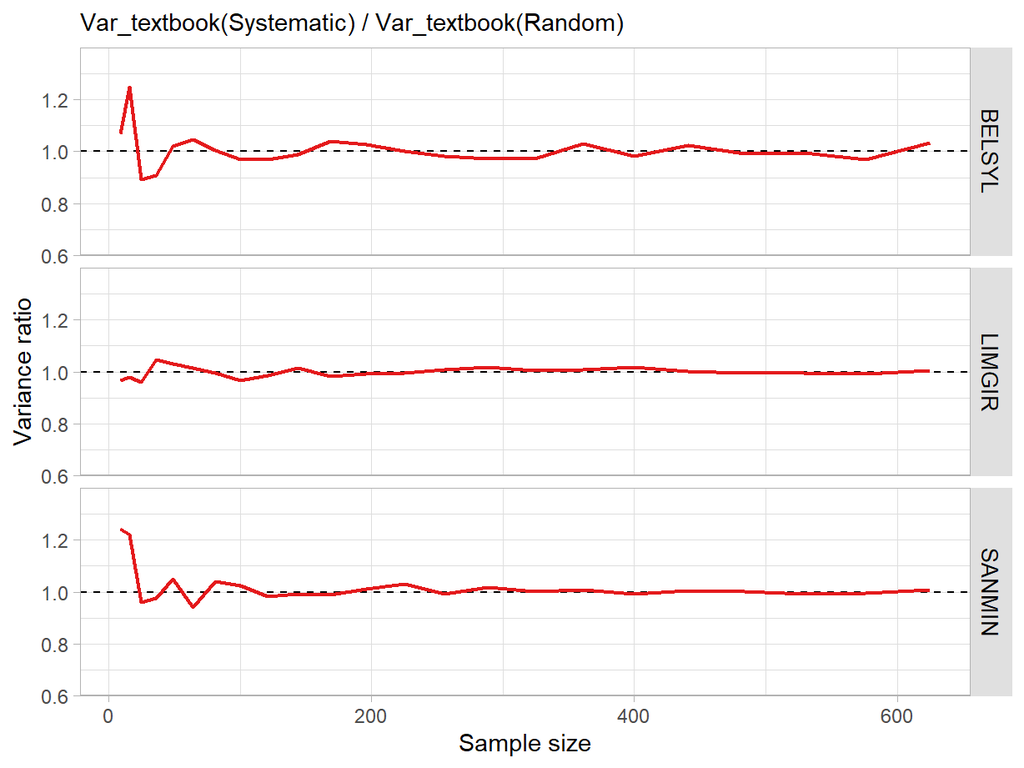

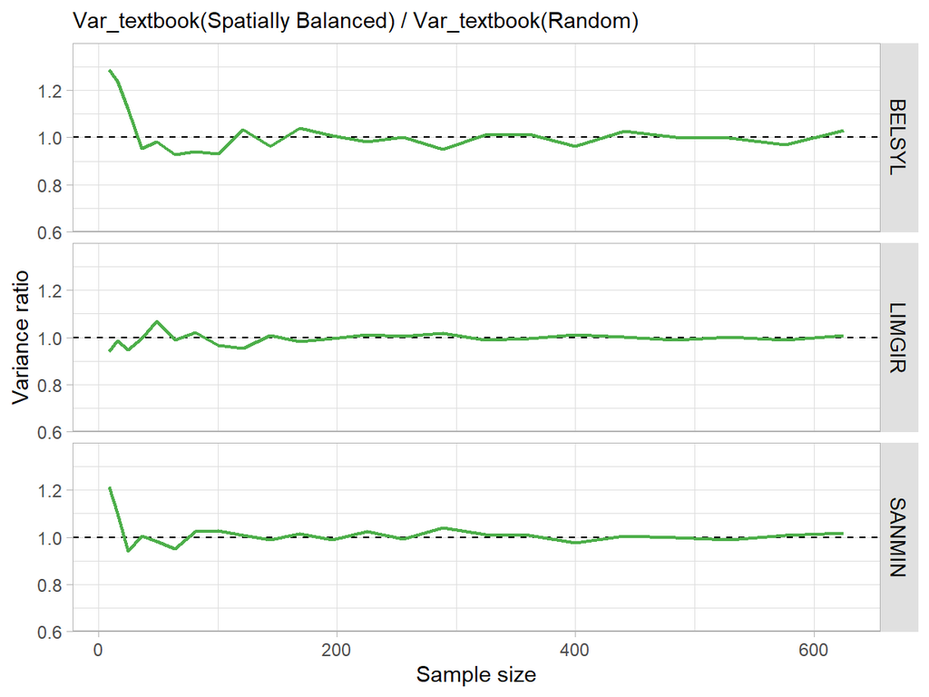

**Figure S4.16:** Ratio of the variance estimated using the “textbook” estimator for systematic sampling (SYS) and spatially balanced sampling (SBS) over the variance estimated for simple random sampling (SRS), as a function of sample size for the three natural populations.

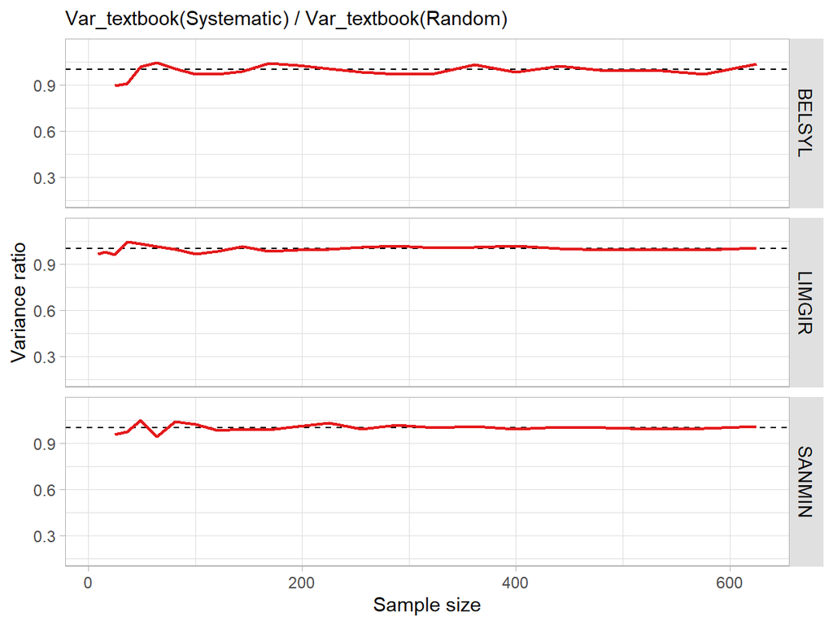

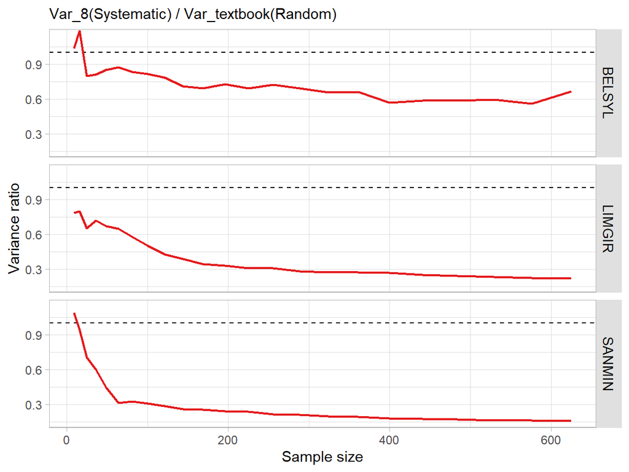

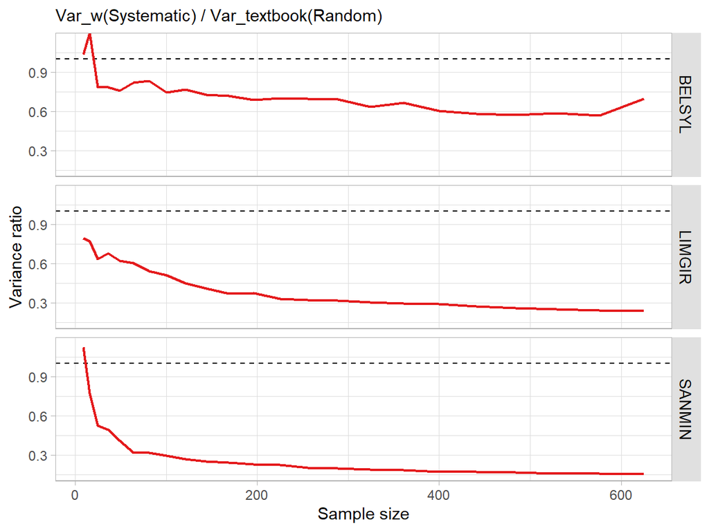

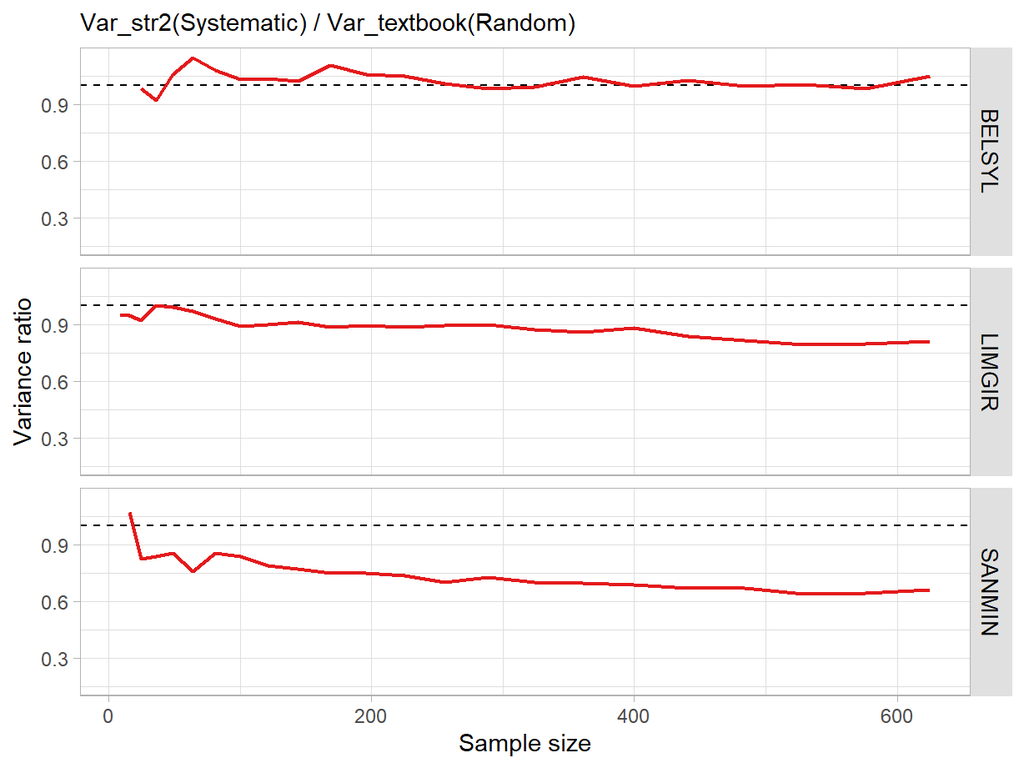

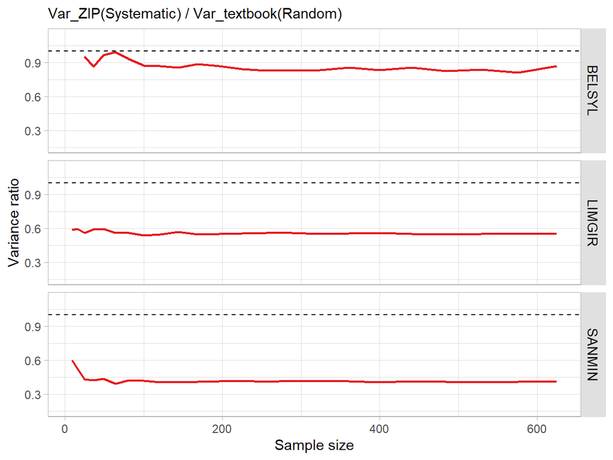

**Figure S4.17:** Ratio of the variance estimated using five variance estimators (V_textbook, V_8, V_w, V_str2, V_ZIP) for systematic sampling (SYS) over the variance estimated using the “textbook” estimator for simple random sampling (SRS), as a function of sample size for the three natural populations.

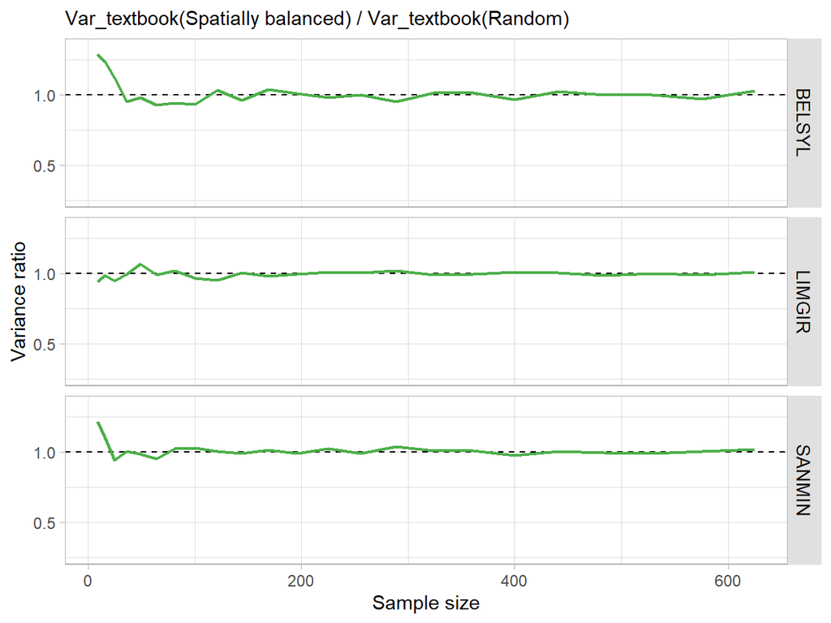

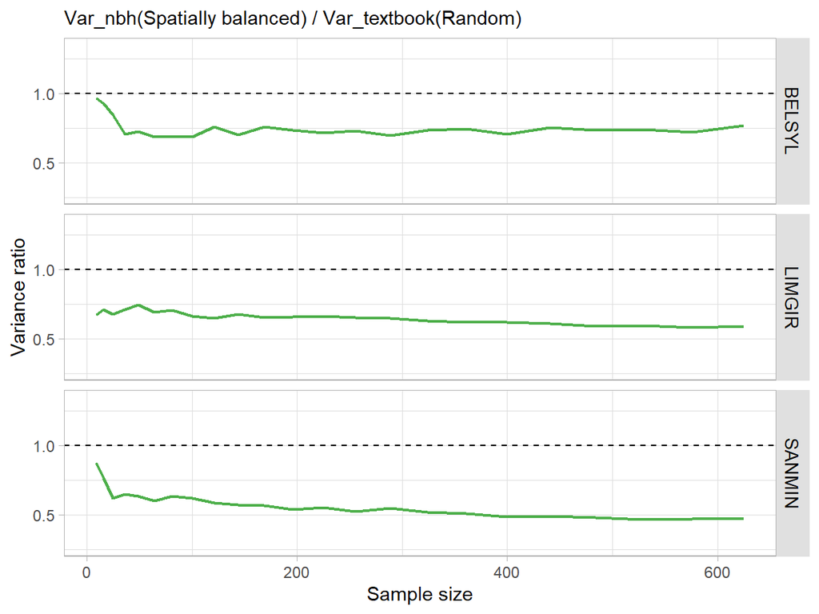

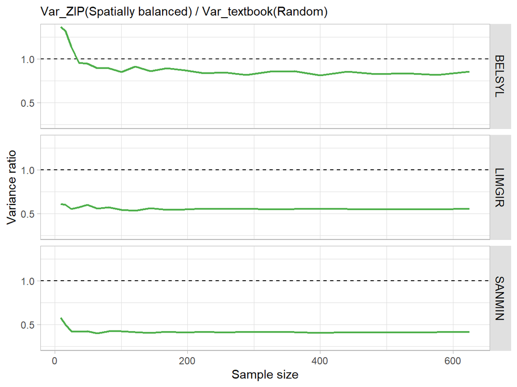

## References

Beckett, S., Jee, J., Ncube, T., Pompilus, S., Washington, Q., Singh, A., & Pal, N. (2014). Zero-inflated Poisson (ZIP) distribution: Parameter estimation and applications to model data from natural calamities. Involve, a Journal of Mathematics, 7(6), 751–767. https://doi.org/10.2140/involve.2014.7.751  
Cochran, W. G. (1977). Sampling Techniques (3rd ed.). John Wiley & Sons.  
D’Orazio, M. (2003). Estimating the variance of the sample mean in two-dimensional systematic sampling. Journal of Agricultural, Biological, and Environmental Statistics, 8(3), 280. https://doi.org/10.1198/1085711032174  
Grafström, A., Lundström, N. L. P., & Schelin, L. (2012). Spatially Balanced Sampling through the Pivotal Method. Biometrics, 68(2), 514–520. https://doi.org/10.1111/j.1541-0420.2011.01699.x  
Jackman, S., Tahk, with contributions from A., Zeileis, A., Maimone, C., & Meers, J. F. and Z. (2020). pscl: Political Science Computational Laboratory (1.5.5). https://CRAN.R-project.org/package=pscl  
Magnussen, S., & Fehrmann, L. (2019). In search of a variance estimator for systematic sampling. Scandinavian Journal of Forest Research, 34(4), 300–312. https://doi.org/10.1080/02827581.2019.1599063  
Magnussen, S., McRoberts, R. E., Breidenbach, J., Nord-Larsen, T., Ståhl, G., Fehrmann, L., & Schnell, S. (2020). Comparison of estimators of variance for forest inventories with systematic sampling—Results from artificial populations. Forest Ecosystems, 7(1), 17. https://doi.org/10.1186/s40663-020-00223-6  
McGarvey, R., Burch, P., & Matthews, J. M. (2016). Precision of systematic and random sampling in clustered populations: Habitat patches and aggregating organisms. Ecological Applications, 26(1), 233–248. https://doi.org/10.1890/14-1973  
Robertson, B. L., Brown, J. A., McDonald, T., & Jaksons, P. (2013). BAS: Balanced Acceptance Sampling of Natural Resources. Biometrics, 69(3), 776–784. https://doi.org/10.1111/biom.12059  
Stevens, D. L., & Olsen, A. R. (2003). Variance estimation for spatially balanced samples of environmental resources. Environmetrics, 14(6), 593–610. https://doi.org/10.1002/env.606  
Thompson, S. K. (2012). Sampling (3rd ed.). Wiley.  
Wolter, K. M. (2007). Introduction to Variance Estimation (2nd ed.). Springer Science & Business Media.